# R Notebook

```r
library(tidyverse)
library(lubridate)
library(tsibble)
library(tsibbledata)
library(fable)
```

# Question 1

Load in the `nyc_bikes` data from the `tsibbledata` package. Have an initial look at it to see what you’re working with. Create three new columns: one that stores only the year the bike was used, one that stores only the month the bike was used, and one that stores the date. Use the data stored in `start_time` to create these new columns.

```r
nyc_bikes %>%
  select(start_time)
```

| start_time | bike_id |
| --- | --- |
| 2018-02-26 19:11:03 | 26301 |
| 2018-02-27 07:52:49 | 26301 |
| 2018-02-27 12:03:27 | 26301 |
| 2018-02-27 13:53:51 | 26301 |
| 2018-02-27 14:30:42 | 26301 |
| 2018-02-27 16:31:04 | 26301 |
| 2018-02-27 17:37:12 | 26301 |
| 2018-02-27 17:49:10 | 26301 |
| 2018-02-27 18:21:57 | 26301 |
| 2018-02-27 22:08:55 | 26301 |

[output cut: 990 more lines]

```r
nyc_bikes <- nyc_bikes %>%
  mutate(year_of_use = year(start_time)) %>%
  mutate(month_of_use =month(start_time)) %>%
  mutate(date_of_use = date(start_time)
         )

nyc_bikes
```

| bike_id | start_time | stop_time | start_station | start_lat | start_long | end_station | end_lat | end_long | type | birth_year | gender | year | month | date | year_of_use | month_of_use | date_of_use |
| --- | --- | --- | --- | --- | --- | --- | --- | --- | --- | --- | --- | --- | --- | --- | --- | --- | --- |
| 26301 | 2018-02-26 19:11:03 | 2018-02-26 19:15:40 | 3186 | 40.71959 | -74.04312 | 3203 | 40.72760 | -74.04425 | Subscriber | 1986 | Male | 2018 | 2 | 2018-02-26 | 2018 | 2 | 2018-02-26 |
| 26301 | 2018-02-27 07:52:49 | 2018-02-27 07:58:13 | 3203 | 40.72760 | -74.04425 | 3202 | 40.72722 | -74.03376 | Subscriber | 1979 | Male | 2018 | 2 | 2018-02-27 | 2018 | 2 | 2018-02-27 |
| 26301 | 2018-02-27 12:03:27 | 2018-02-27 12:04:54 | 3202 | 40.72722 | -74.03376 | 3638 | 40.72429 | -74.03548 | Subscriber | 1963 | Male | 2018 | 2 | 2018-02-27 | 2018 | 2 | 2018-02-27 |
| 26301 | 2018-02-27 13:53:51 | 2018-02-27 14:21:04 | 3638 | 40.72429 | -74.03548 | 3638 | 40.72429 | -74.03548 | Subscriber | 1984 | Male | 2018 | 2 | 2018-02-27 | 2018 | 2 | 2018-02-27 |
| 26301 | 2018-02-27 14:30:42 | 2018-02-27 14:33:11 | 3638 | 40.72429 | -74.03548 | 3187 | 40.72112 | -74.03805 | Subscriber | 1980 | Male | 2018 | 2 | 2018-02-27 | 2018 | 2 | 2018-02-27 |
| 26301 | 2018-02-27 16:31:04 | 2018-02-27 16:33:27 | 3187 | 40.72112 | -74.03805 | 3638 | 40.72429 | -74.03548 | Subscriber | 1980 | Male | 2018 | 2 | 2018-02-27 | 2018 | 2 | 2018-02-27 |
| 26301 | 2018-02-27 17:37:12 | 2018-02-27 17:40:49 | 3638 | 40.72429 | -74.03548 | 3639 | 40.71925 | -74.03423 | Subscriber | 1989 | Male | 2018 | 2 | 2018-02-27 | 2018 | 2 | 2018-02-27 |
| 26301 | 2018-02-27 17:49:10 | 2018-02-27 17:55:03 | 3639 | 40.71925 | -74.03423 | 3202 | 40.72722 | -74.03376 | Subscriber | 1962 | Male | 2018 | 2 | 2018-02-27 | 2018 | 2 | 2018-02-27 |
| 26301 | 2018-02-27 18:21:57 | 2018-02-27 18:25:18 | 3202 | 40.72722 | -74.03376 | 3638 | 40.72429 | -74.03548 | Subscriber | 1992 | Male | 2018 | 2 | 2018-02-27 | 2018 | 2 | 2018-02-27 |
| 26301 | 2018-02-27 22:08:55 | 2018-02-27 22:28:42 | 3638 | 40.72429 | -74.03548 | 3281 | 40.74591 | -74.05727 | Subscriber | 1981 | Male | 2018 | 2 | 2018-02-27 | 2018 | 2 | 2018-02-27 |

[output cut: 990 more lines]

```r
NA
```

# Question 2

Summarise the number of bike hire counts by month. Make a plot of this data. *Hint: remember that to group time series (`tsibble`) data, you need to use `index_by` instead of `group_by` before your summarise function. What does this plot tell you about the time series?

It is seasonal.

Do you think this downsampled data would be adequate to build a forecast with?  
possibly not.

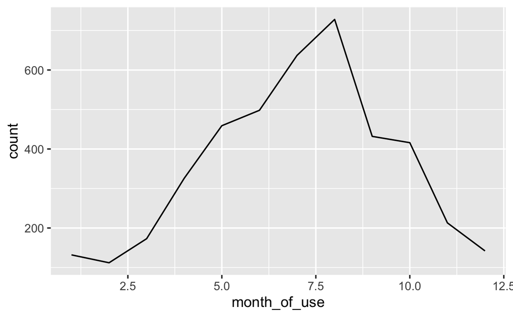

```r
nyc_bikes %>%
  index_by(month_of_use)  %>%
  summarise(count = n()) %>%
  ggplot() +
  geom_line(aes(x = month_of_use, y = count))
```